# covid 19

Nicole Orizino

Spring 2021

### Data is from the Patient_Info dataset from South Korea 1 Jan to 1 May

### This is contained in a downloadable zip file from kaggle

Some of the data was uncoded for sex - sex must be just male or female 77 of the data entries were coded sex as blank, so we omit these. state of a patient must be died or alive - we adjust that as well

# Question 1 - Is dying independent of sex

$H_0$: Covid 19 deaths in Korea, Jam-May 2020 are unrelated $H_A$: There is a relation between deaths in Korea Jan-May 2020 and sex of the patient

Table of patients:

```r
kRdata$Sex = as.factor(kRdata$Sex)
kRdata$result = as.factor(kRdata$result)


# cross tabulation, patient state by gender

with(kRdata, table(Sex, result))
```

```
##    result
## Sex alive dead
##   F  1831   25
##   M  1411   44
```

This chart shows that more males died from covid than female, with a 25 for female and 44 for male.

## We create two bar charts - one based on frequency and the other on percent, use ggplot commands to do this

```r
dd2 <- kRdata %>% group_by(result,Sex) %>% summarize(count=n()) %>% mutate(prcnt=count/sum(count))
```

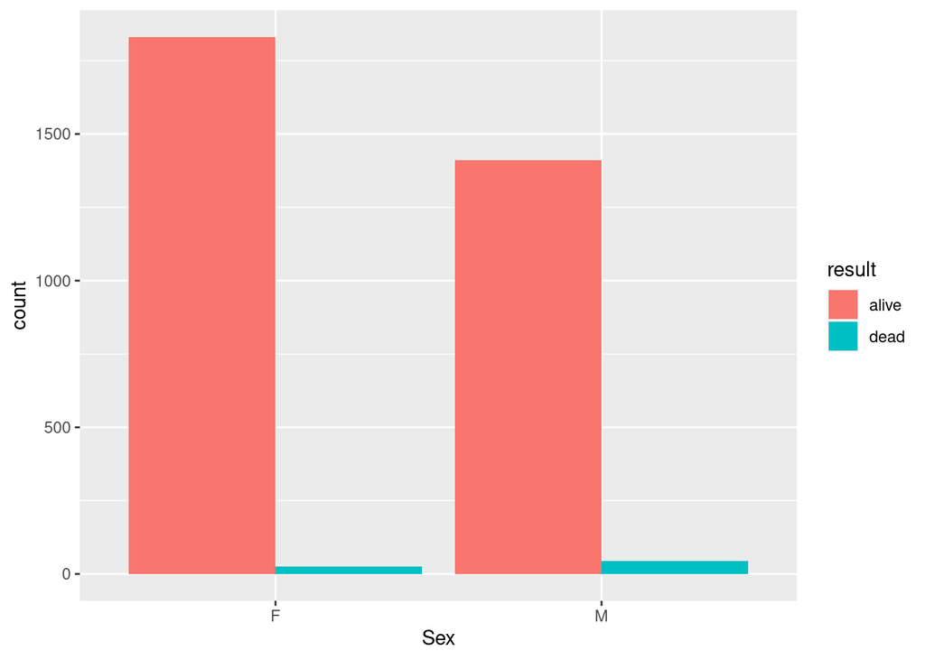

```r
# the group_by followed by summarize(count=n())

basicC <- ggplot(dd2,aes(x=Sex,y=count,fill=result))
basicC + geom_bar(stat="identity",position="dodge")
```

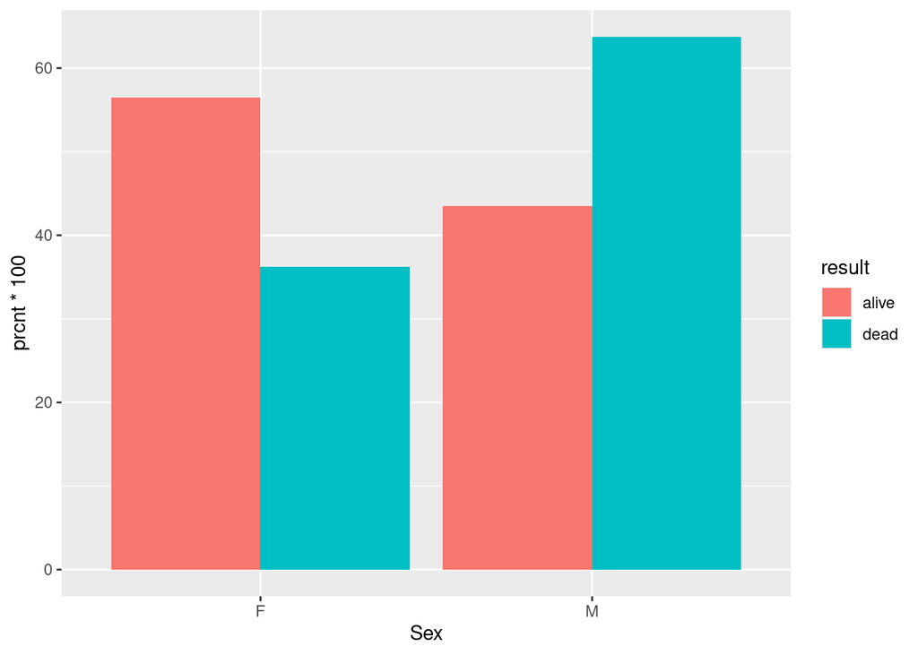

```r
#Now for percentage plot

basicCC <- ggplot(dd2,aes(x=Sex,y=prcnt*100,fill=result))
basicCC + geom_bar(stat="identity", position = "dodge")
```

Both graphs show that the female sex in Korea survived more that the male sex of those who caught Covid 19.

## Numerical results

```r
table1 <- xtabs(~result + Sex, data=kRdata)
rowPerc(table1)
```

```
##        Sex
## result    F   M Total
##   alive  56  44   100
##   dead   36  64   100
```

```r
colPerc(table1)
```

```
##        Sex
## result      F   M
##   alive  98.7  97
##   dead    1.4   3
##   Total 100.0 100
```

The Numerical results also shows that more females lived while more males died. 56f vs 44m alive and 36f vs 64m dead.

## Inferential results

```r
chisq.test(table1)
```

```
##
##  Pearson's Chi-squared test with Yates' continuity correction
##
## data:  table1
## X-squared = 10, df = 1, p-value = 0.001
```

```r
chisqtestGC(table1)
```

```
## Pearson's Chi-squared test with Yates' continuity correction
##
## Observed Counts:
##        Sex
## result     F    M
##   alive 1831 1411
##   dead    25   44
##
## Counts Expected by Null:
##        Sex
## result     F    M
##   alive 1817 1425
##   dead    39   30
##
## Contributions to the chi-square statistic:
##        Sex
## result     F    M
##   alive 0.10 0.13
##   dead  4.84 6.17
##
##
## Chi-Square Statistic = 10
## Degrees of Freedom of the table = 1
## P-Value = 0.0012
```

```r
fisher.test(table1)
```

```
##
##  Fisher's Exact Test for Count Data
##
## data:  table1
## p-value = 9e-04
## alternative hypothesis: true odds ratio is not equal to 1
## 95 percent confidence interval:
##  1.4 3.9
## sample estimates:
## odds ratio
##        2.3
```

The P-value is .001 and in all the results (observed,expected by Null and chi-square statistics) shows that females survived covid more than men. Resulting in Reject the Null Hypothesis. The odds ratio also shows males are 2.3 more times to die due to covid.

## Conclusions

The question was is dying independent of sex? The conclusion to this question is, we reject the null hypothesis. The P-value is .001 meaning it is a small number. And all the graphs here show that more females survived covid 19 than male.